# Owl Vocalization data analysis

Youngwoo Kwon

2022-06-17

#### This report analyzed the relationship between the behavior of owls and the data of Owl vocalization data.

#### We selected the useful parameters, and constructed new parameters in the vocalization data that might be significant for different behaviors.

#### We signified one specific behavior, chuckles, which had distinctly different vocalization from other behaviors. Also, we specified the name of each chuckles vocalization data; Rupert, Rupert with towel, Savannah Georgia female.

#### We selected two owls, owl #1 and #55, accounted for the about one third of the data.

#### We tried student’s t-test and Welch’s t-test to test the hypothesis whether the selected parameters are unique or not during specific behaviors in selected groups.

#### We displayed QQ-plot to check whether the data are following normal assumptions.

#### We tried the permutation test to check whether the selected parameters are unique or not during specific behaviors in selected groups even if the total data is not following the normal assumption.

#### Overall, in many cases, the parameter pulsrate was significant between two data groups which consisted of chuckles / not chuckles . Two other parameter of interest, duration and bandwidth, were not significant in many cases. Detailed results can be found in Section 5.

### Data cleaning

```r
colname2 = c("Begin Time (s)_s", "End Time (s)_s", "Low Freq (Hz)_s", "High Freq (Hz)_s", "Center Freq (Hz)_s", "Q1 Freq (Hz)_s", "Q3 Freq (Hz)_s", "IQR BW (Hz)_s", "IQR Dur (s)_s", "BW 90% (Hz)_s","Center Time (s)_s", "Q1 Time (s)_s", "Q3 Time (s)_s", "Peak Time (s)_s", "Max Time (s)_s", "Peak Freq (Hz)_s", "Delta Freq (Hz)_s",  "Delta Time (s)_s", "Freq 5% (Hz)_s", "Freq 95% (Hz)_s", "Time 95% (s)_w",  "Time 5% (s)_s", "Dur 90% (s)_s", "Age_s", "Sex_s", "Imprint status_s", "to human_s", "hoot_s", "Owl ID #_s", "Units (notes)", "Period", "Favored", "chuckles")
```

```r
dat_0 = read_excel("data/data_2.xlsx")[-350,]
```

```r
dat_1 = dat_0[,colname2]
```

```r
dat_2 = dat_1
```

```r
cor = c()
for(i in 1:ncol(dat_2)){
  coln = colnames(dat_2)[i]
  dat_2[,i] = as.numeric(pull(dat_2, coln))
}
dat_2[,25] = as.factor(pull(dat_2, colnames(dat_2)[25]))
```

```r
rep = c(rep(0,344) ,1,1,1,1,1)
dat_2$response = rep
rep2 = c(rep(0,344), 0,0,1,1,0)
dat_2$chuckles = rep2
```

```r
dat_2$duration = dat_2$`End Time (s)_s` - dat_2$`Begin Time (s)_s`
dat_2$pulsepertime = dat_2$`Units (notes)` /dat_2$duration
dat_2$pulserate = dat_2$duration / dat_2$`Units (notes)`
dat_2$halftime = (dat_2$`Q3 Time (s)_s` - dat_2$`Q1 Time (s)_s`) / dat_2$duration
```

```r
dat_ch = dat_2 %>% filter(chuckles == 1)
dat_nch1 = dat_2 %>% filter(response == 1) %>% filter(chuckles == 0) %>% filter(`Owl ID #_s` == 1)
dat_nch2 = dat_2 %>% filter(response == 1) %>% filter(chuckles == 0) %>% filter(`Owl ID #_s` == 55)
```

```r
dat_id1 = dat_2 %>% filter(response == 0) %>% filter(`Units (notes)` > 1) %>% filter(`Owl ID #_s` == 1)
dat_id2 = dat_2 %>% filter(response == 0) %>% filter(`Units (notes)` > 1) %>% filter(`Owl ID #_s` == 55)

dat_4 = dat_2 %>% filter(response == 1) %>% filter(chuckles == 0)
```

## 1 Student’s t-test

### 1.1 Rupert vs. all ID#1 vocalizations where units >1

```r
t.test(dat_ch$pulserate, dat_id1$pulserate, var.equal = TRUE)
```

```
##
##  Two Sample t-test
##
## data:  dat_ch$pulserate and dat_id1$pulserate
## t = -3.6647, df = 35, p-value = 0.0008135
## alternative hypothesis: true difference in means is not equal to 0
## 95 percent confidence interval:
##  -0.4395887 -0.1261763
## sample estimates:
## mean of x mean of y
## 0.0030000 0.2858825
```

```r
t.test(dat_ch$duration, dat_id1$duration, var.equal = TRUE)
```

```
##
##  Two Sample t-test
##
## data:  dat_ch$duration and dat_id1$duration
## t = -1.7841, df = 35, p-value = 0.08309
## alternative hypothesis: true difference in means is not equal to 0
## 95 percent confidence interval:
##  -5.6218082  0.3626551
## sample estimates:
## mean of x mean of y
##  0.033000  2.662577
```

```r
t.test(dat_ch$`IQR BW (Hz)_s`, dat_id1$`IQR BW (Hz)_s`, var.equal = TRUE)
```

```
##
##  Two Sample t-test
##
## data:  dat_ch$`IQR BW (Hz)_s` and dat_id1$`IQR BW (Hz)_s`
## t = 0.15066, df = 35, p-value = 0.8811
## alternative hypothesis: true difference in means is not equal to 0
## 95 percent confidence interval:
##  -234.8055  272.4512
## sample estimates:
## mean of x mean of y
##  375.0000  356.1771
```

### 1.2 Rupert with towel vs Savannah Georgia female

```r
t.test(dat_nch1$pulserate, dat_nch2$pulserate, var.equal = TRUE)
```

```
##
##  Two Sample t-test
##
## data:  dat_nch1$pulserate and dat_nch2$pulserate
## t = -1.666, df = 1, p-value = 0.3442
## alternative hypothesis: true difference in means is not equal to 0
## 95 percent confidence interval:
##  -0.3155238  0.2423738
## sample estimates:
## mean of x mean of y
##  0.295500  0.332075
```

```r
t.test(dat_nch1$duration, dat_nch2$duration, var.equal = TRUE)
```

```
##
##  Two Sample t-test
##
## data:  dat_nch1$duration and dat_nch2$duration
## t = 1.5096, df = 1, p-value = 0.3725
## alternative hypothesis: true difference in means is not equal to 0
## 95 percent confidence interval:
##  -2.113849  2.683849
## sample estimates:
## mean of x mean of y
##     1.773     1.488
```

```r
t.test(dat_nch1$`IQR BW (Hz)_s`, dat_nch2$`IQR BW (Hz)_s`, var.equal = TRUE)
```

```
##
##  Two Sample t-test
##
## data:  dat_nch1$`IQR BW (Hz)_s` and dat_nch2$`IQR BW (Hz)_s`
## t = -1.1207, df = 1, p-value = 0.4638
## alternative hypothesis: true difference in means is not equal to 0
## 95 percent confidence interval:
##  -8766.502  7345.402
## sample estimates:
## mean of x mean of y
##    430.70   1141.25
```

### 1.3 Rupert with towel vs all #1 vocalizations where units >1

```r
t.test(dat_nch1$pulserate, dat_id1$pulserate, var.equal = TRUE)
```

```
##
##  Two Sample t-test
##
## data:  dat_nch1$pulserate and dat_id1$pulserate
## t = 0.088031, df = 34, p-value = 0.9304
## alternative hypothesis: true difference in means is not equal to 0
## 95 percent confidence interval:
##  -0.212408  0.231643
## sample estimates:
## mean of x mean of y
## 0.2955000 0.2858825
```

```r
t.test(dat_nch1$duration, dat_id1$duration, var.equal = TRUE)
```

```
##
##  Two Sample t-test
##
## data:  dat_nch1$duration and dat_id1$duration
## t = -0.42643, df = 34, p-value = 0.6725
## alternative hypothesis: true difference in means is not equal to 0
## 95 percent confidence interval:
##  -5.129050  3.349897
## sample estimates:
## mean of x mean of y
##  1.773000  2.662577
```

```r
t.test(dat_nch1$`IQR BW (Hz)_s`, dat_id1$`IQR BW (Hz)_s`, var.equal = TRUE)
```

```
##
##  Two Sample t-test
##
## data:  dat_nch1$`IQR BW (Hz)_s` and dat_id1$`IQR BW (Hz)_s`
## t = 0.42145, df = 34, p-value = 0.6761
## alternative hypothesis: true difference in means is not equal to 0
## 95 percent confidence interval:
##  -284.8247  433.8704
## sample estimates:
## mean of x mean of y
##  430.7000  356.1771
```

### 1.4 Savannah Georgia female vs all Savannah Georgia female vocalizations where Units>1.

```r
t.test(dat_nch2$pulserate, dat_id2$pulserate, var.equal = TRUE)
```

```
##
##  Two Sample t-test
##
## data:  dat_nch2$pulserate and dat_id2$pulserate
## t = 0.61586, df = 69, p-value = 0.54
## alternative hypothesis: true difference in means is not equal to 0
## 95 percent confidence interval:
##  -0.08909129  0.16866263
## sample estimates:
## mean of x mean of y
## 0.3320750 0.2922893
```

```r
t.test(dat_nch2$duration, dat_id2$duration, var.equal = TRUE)
```

```
##
##  Two Sample t-test
##
## data:  dat_nch2$duration and dat_id2$duration
## t = -0.86101, df = 69, p-value = 0.3922
## alternative hypothesis: true difference in means is not equal to 0
## 95 percent confidence interval:
##  -6.812552  2.704883
## sample estimates:
## mean of x mean of y
##  1.488000  3.541834
```

```r
t.test(dat_nch2$`IQR BW (Hz)_s`, dat_id2$`IQR BW (Hz)_s`, var.equal = TRUE)
```

```
##
##  Two Sample t-test
##
## data:  dat_nch2$`IQR BW (Hz)_s` and dat_id2$`IQR BW (Hz)_s`
## t = 1.5933, df = 69, p-value = 0.1157
## alternative hypothesis: true difference in means is not equal to 0
## 95 percent confidence interval:
##  -130.7927 1168.4261
## sample estimates:
## mean of x mean of y
## 1141.2500  622.4333
```

### 1.5 Rupert vs. ((all ID #1 and all ID #55) where units > 1)

```r
dat_3 = dat_2 %>% filter(response == 0) %>% filter(`Owl ID #_s` %in% c(1, 55)) %>% filter(`Units (notes)` > 1)

t.test(dat_ch$pulserate, dat_3$pulserate, var.equal = TRUE)
```

```
##
##  Two Sample t-test
##
## data:  dat_ch$pulserate and dat_3$pulserate
## t = -4.1976, df = 104, p-value = 5.699e-05
## alternative hypothesis: true difference in means is not equal to 0
## 95 percent confidence interval:
##  -0.4227803 -0.1514861
## sample estimates:
## mean of x mean of y
## 0.0030000 0.2901332
```

```r
t.test(dat_ch$duration, dat_3$duration, var.equal = TRUE)
```

```
##
##  Two Sample t-test
##
## data:  dat_ch$duration and dat_3$duration
## t = -1.5092, df = 104, p-value = 0.1343
## alternative hypothesis: true difference in means is not equal to 0
## 95 percent confidence interval:
##  -7.434568  1.008707
## sample estimates:
## mean of x mean of y
##   0.03300   3.24593
```

```r
t.test(dat_ch$`IQR BW (Hz)_s`, dat_3$`IQR BW (Hz)_s`, var.equal = TRUE)
```

```
##
##  Two Sample t-test
##
## data:  dat_ch$`IQR BW (Hz)_s` and dat_3$`IQR BW (Hz)_s`
## t = -0.55285, df = 104, p-value = 0.5816
## alternative hypothesis: true difference in means is not equal to 0
## 95 percent confidence interval:
##  -723.9497  408.2939
## sample estimates:
## mean of x mean of y
##  375.0000  532.8279
```

### 1.6 Rupert vs Savannah Gerogia female

```r
t.test(dat_ch$pulserate, dat_nch2$pulserate, var.equal = TRUE)
```

```
##
##  Two Sample t-test
##
## data:  dat_ch$pulserate and dat_nch2$pulserate
## t = -25.957, df = 2, p-value = 0.001481
## alternative hypothesis: true difference in means is not equal to 0
## 95 percent confidence interval:
##  -0.3836237 -0.2745263
## sample estimates:
## mean of x mean of y
##  0.003000  0.332075
```

```r
t.test(dat_ch$duration, dat_nch2$duration, var.equal = TRUE)
```

```
##
##  Two Sample t-test
##
## data:  dat_ch$duration and dat_nch2$duration
## t = -13.344, df = 2, p-value = 0.005569
## alternative hypothesis: true difference in means is not equal to 0
## 95 percent confidence interval:
##  -1.9241667 -0.9858333
## sample estimates:
## mean of x mean of y
##     0.033     1.488
```

```r
t.test(dat_ch$`IQR BW (Hz)_s`, dat_nch2$`IQR BW (Hz)_s`, var.equal = TRUE)
```

```
##
##  Two Sample t-test
##
## data:  dat_ch$`IQR BW (Hz)_s` and dat_nch2$`IQR BW (Hz)_s`
## t = -2.0933, df = 2, p-value = 0.1714
## alternative hypothesis: true difference in means is not equal to 0
## 95 percent confidence interval:
##  -2341.236   808.736
## sample estimates:
## mean of x mean of y
##    375.00   1141.25
```

### 1.7 Rupert vs Rupert with towel

```r
t.test(dat_ch$pulserate, dat_nch1$pulserate, var.equal = TRUE)
```

```
##
##  Two Sample t-test
##
## data:  dat_ch$pulserate and dat_nch1$pulserate
## t = -619.21, df = 1, p-value = 0.001028
## alternative hypothesis: true difference in means is not equal to 0
## 95 percent confidence interval:
##  -0.2985021 -0.2864979
## sample estimates:
## mean of x mean of y
##    0.0030    0.2955
```

```r
t.test(dat_ch$duration, dat_nch1$duration, var.equal = TRUE)
```

```
##
##  Two Sample t-test
##
## data:  dat_ch$duration and dat_nch1$duration
## t = -334.86, df = 1, p-value = 0.001901
## alternative hypothesis: true difference in means is not equal to 0
## 95 percent confidence interval:
##  -1.806023 -1.673977
## sample estimates:
## mean of x mean of y
##     0.033     1.773
```

```r
#t.test(dat_ch$`IQR BW (Hz)_s`, dat_nch1$`IQR BW (Hz)_s`, var.equal = TRUE)
```

### 1.8 Savannah Georgia female vs ((all ID #1 and all ID #55) where units > 1)

```r
t.test(dat_nch2$pulserate, dat_3$pulserate, var.equal = TRUE)
```

```
##
##  Two Sample t-test
##
## data:  dat_nch2$pulserate and dat_3$pulserate
## t = 0.61305, df = 104, p-value = 0.5412
## alternative hypothesis: true difference in means is not equal to 0
## 95 percent confidence interval:
##  -0.09372809  0.17761172
## sample estimates:
## mean of x mean of y
## 0.3320750 0.2901332
```

```r
t.test(dat_nch2$duration, dat_3$duration, var.equal = TRUE)
```

```
##
##  Two Sample t-test
##
## data:  dat_nch2$duration and dat_3$duration
## t = -0.82575, df = 104, p-value = 0.4108
## alternative hypothesis: true difference in means is not equal to 0
## 95 percent confidence interval:
##  -5.979622  2.463761
## sample estimates:
## mean of x mean of y
##   1.48800   3.24593
```

```r
t.test(dat_nch2$`IQR BW (Hz)_s`, dat_3$`IQR BW (Hz)_s`, var.equal = TRUE)
```

```
##
##  Two Sample t-test
##
## data:  dat_nch2$`IQR BW (Hz)_s` and dat_3$`IQR BW (Hz)_s`
## t = 2.1142, df = 104, p-value = 0.03688
## alternative hypothesis: true difference in means is not equal to 0
## 95 percent confidence interval:
##    37.75771 1179.08652
## sample estimates:
## mean of x mean of y
## 1141.2500  532.8279
```

## 2. Graphs

```r
dat_3[,29] = as.factor(pull(dat_3, colnames(dat_3)[29]))
dat_ch[,29] = as.factor(pull(dat_ch, colnames(dat_ch)[29]))
dat_4[,29] = as.factor(pull(dat_4, colnames(dat_4)[29]))
```

### 2.1 Boxplot_pulserate

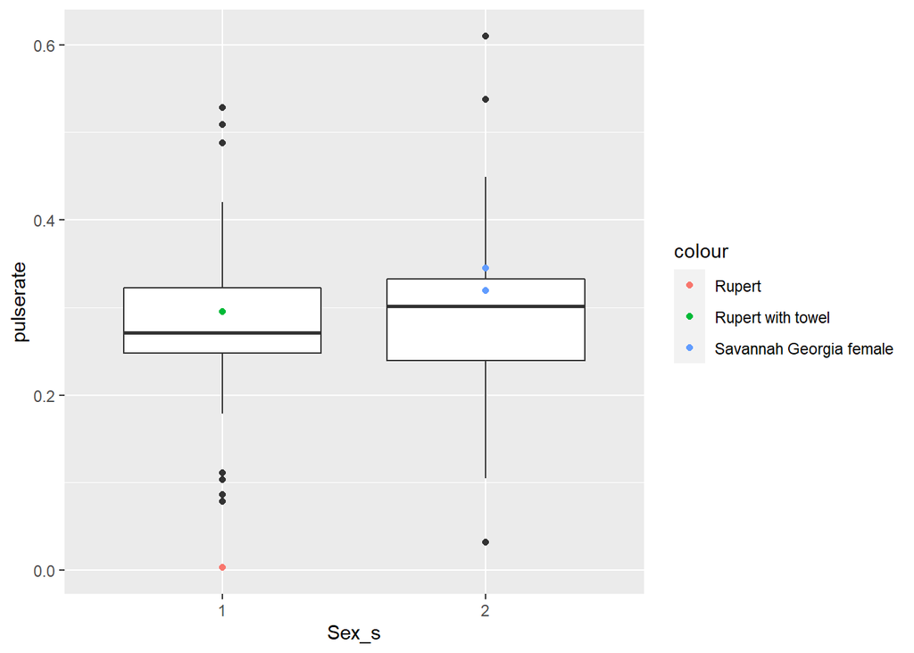

```r
ggplot() +
  geom_boxplot(aes(x= Sex_s, y=pulserate), data = dat_3) +
  geom_point(aes(x=Sex_s, y=pulserate, color = "Rupert"), data=dat_ch) +
  geom_point(aes(x=Sex_s, y=pulserate, color = "Rupert with towel"), data=dat_nch1) +
  geom_point(aes(x=Sex_s, y=pulserate, color = "Savannah Georgia female"), data=dat_nch2)
```

### 2.2 Boxplot_Duration

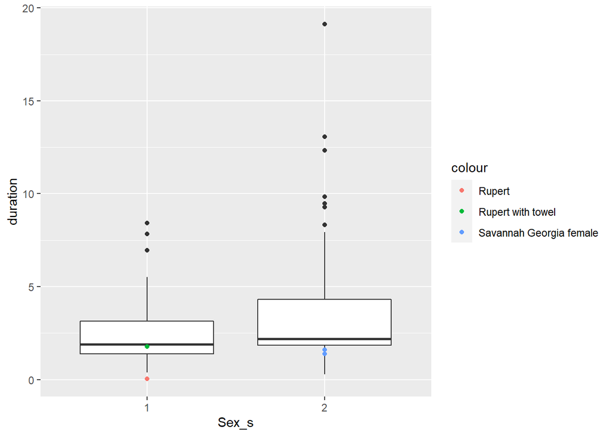

```r
ggplot() +
  geom_boxplot(aes(x= Sex_s, y=duration), data = dat_3) +
  geom_point(aes(x=Sex_s, y=duration, color = "Rupert"), data=dat_ch) +
  geom_point(aes(x=Sex_s, y=duration, color = "Rupert with towel"), data=dat_nch1) +
  geom_point(aes(x=Sex_s, y=duration, color = "Savannah Georgia female"), data=dat_nch2)
```

### 2.3 Boxplot_IQR BW

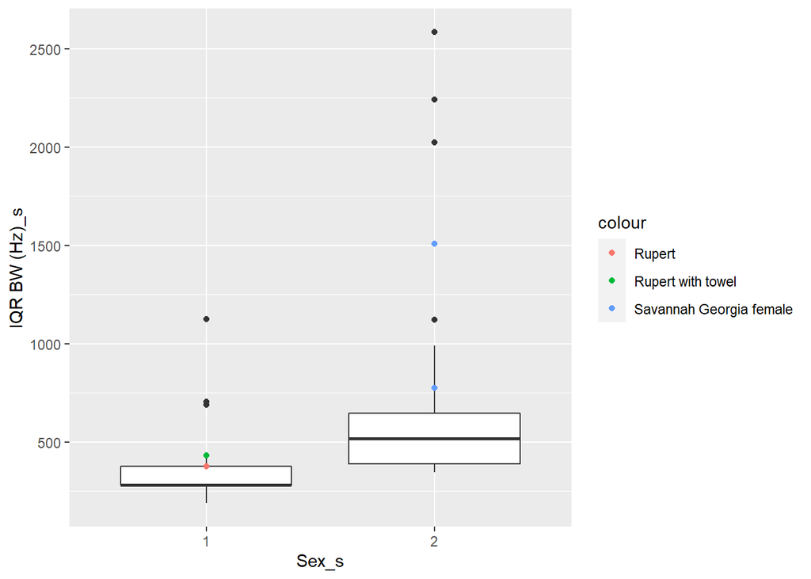

```r
ggplot() +
  geom_boxplot(aes(x= Sex_s, y=`IQR BW (Hz)_s`), data = dat_3) +
  geom_point(aes(x=Sex_s, y=`IQR BW (Hz)_s`, color = "Rupert"), data=dat_ch) +
  geom_point(aes(x=Sex_s, y=`IQR BW (Hz)_s`, color = "Rupert with towel"), data=dat_nch1) +
  geom_point(aes(x=Sex_s, y=`IQR BW (Hz)_s`, color = "Savannah Georgia female"), data=dat_nch2)
```

## 3. QQPlot

### 3.1 QQPlot_dat3

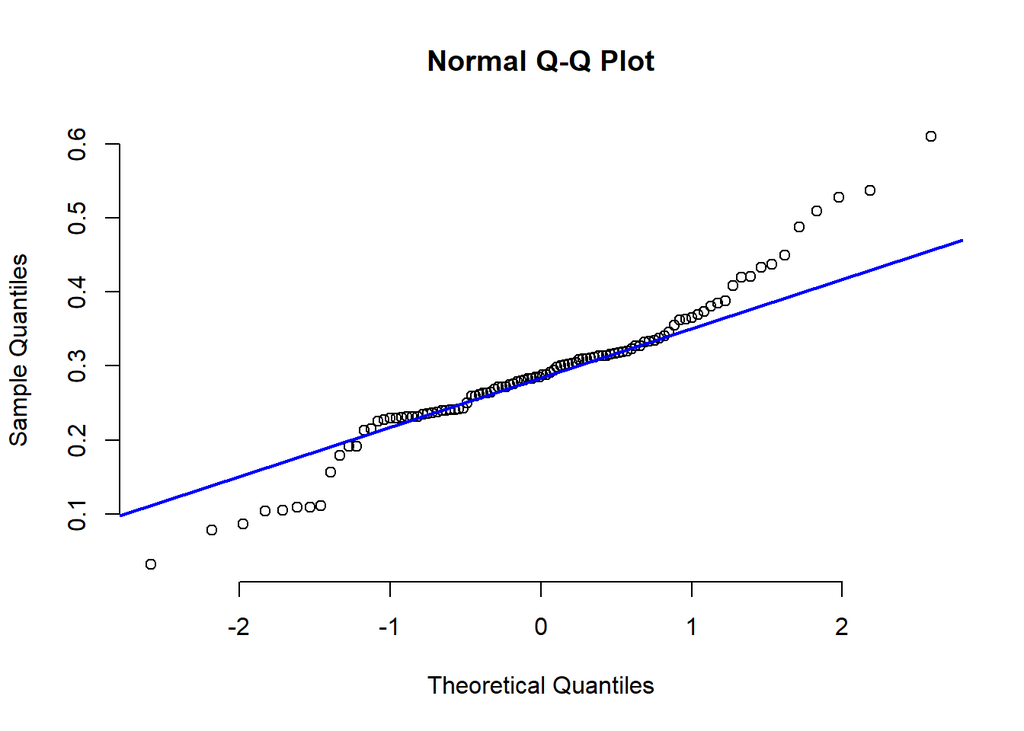

```r
qqnorm(dat_3$pulserate, pch = 1, frame = FALSE)
qqline(dat_3$pulserate, col = "blue", lwd = 2)
```

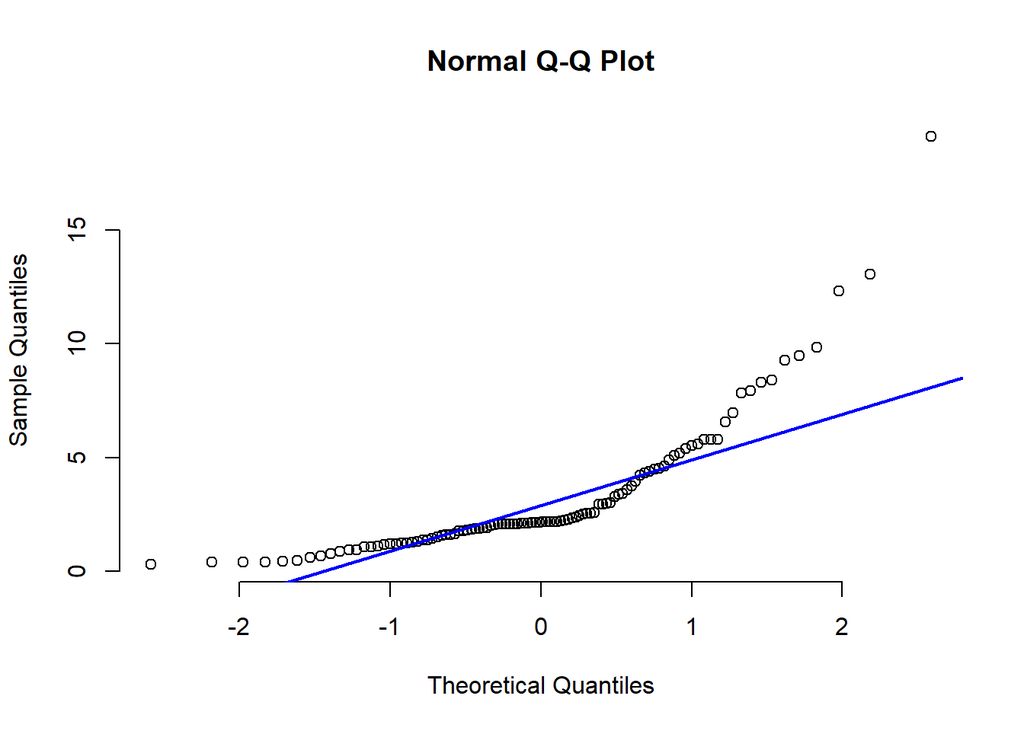

```r
qqnorm(dat_3$duration, pch = 1, frame = FALSE)
qqline(dat_3$duration, col = "blue", lwd = 2)
```

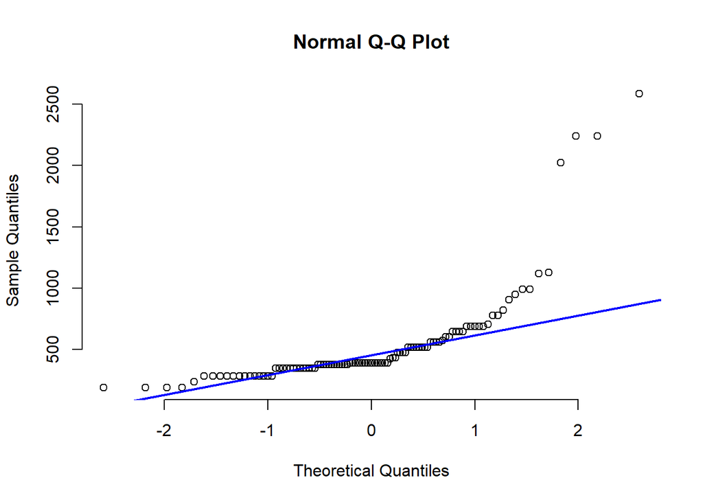

```r
qqnorm(dat_3$`IQR BW (Hz)_s`, pch = 1, frame = FALSE)
qqline(dat_3$`IQR BW (Hz)_s`, col = "blue", lwd = 2)
```

### 3.2 QQPlot_dat2

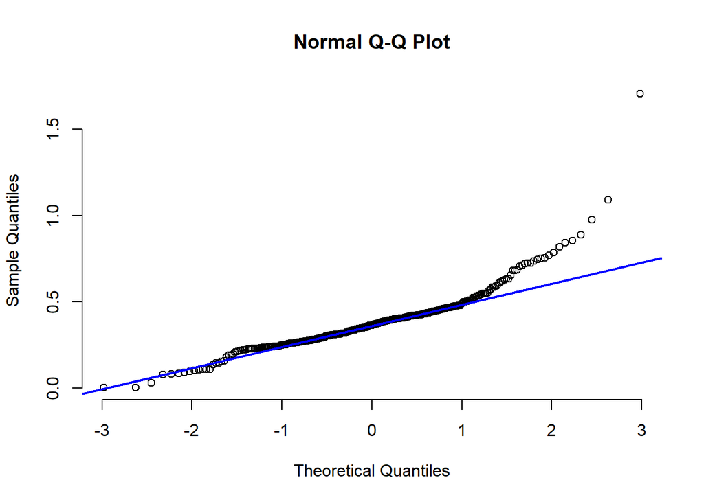

```r
qqnorm(dat_2$pulserate, pch = 1, frame = FALSE)
qqline(dat_2$pulserate, col = "blue", lwd = 2)
```

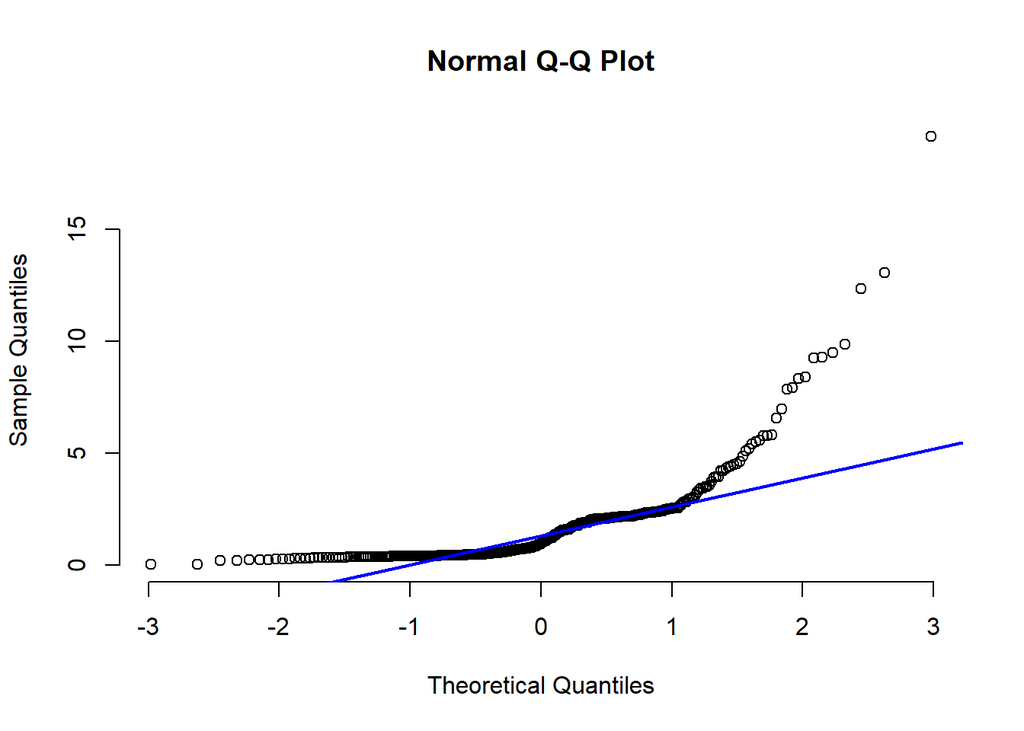

```r
qqnorm(dat_2$duration, pch = 1, frame = FALSE)
qqline(dat_2$duration, col = "blue", lwd = 2)
```

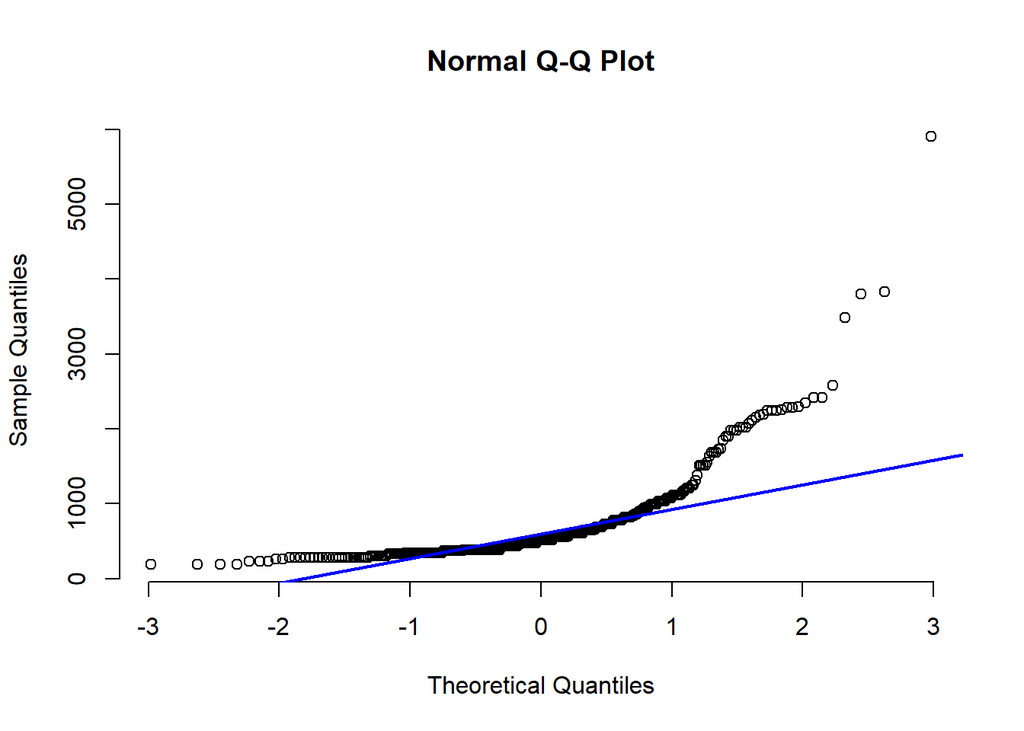

```r
qqnorm(dat_2$`IQR BW (Hz)_s`, pch = 1, frame = FALSE)
qqline(dat_2$`IQR BW (Hz)_s`, col = "blue", lwd = 2)
```

## 4 Welch’s t-test

### 4.1 Rupert vs. all ID#1 vocalizations where units >1

```r
t.test(dat_ch$pulserate, dat_id1$pulserate)
```

```
##
##  Welch Two Sample t-test
##
## data:  dat_ch$pulserate and dat_id1$pulserate
## t = -15.534, df = 34.015, p-value < 2.2e-16
## alternative hypothesis: true difference in means is not equal to 0
## 95 percent confidence interval:
##  -0.3198903 -0.2458747
## sample estimates:
## mean of x mean of y
## 0.0030000 0.2858825
```

```r
t.test(dat_ch$duration, dat_id1$duration)
```

```
##
##  Welch Two Sample t-test
##
## data:  dat_ch$duration and dat_id1$duration
## t = -7.5628, df = 34.005, p-value = 8.76e-09
## alternative hypothesis: true difference in means is not equal to 0
## 95 percent confidence interval:
##  -3.336178 -1.922975
## sample estimates:
## mean of x mean of y
##  0.033000  2.662577
```

```r
t.test(dat_ch$`IQR BW (Hz)_s`, dat_id1$`IQR BW (Hz)_s`)
```

```
##
##  Welch Two Sample t-test
##
## data:  dat_ch$`IQR BW (Hz)_s` and dat_id1$`IQR BW (Hz)_s`
## t = 0.6387, df = 34, p-value = 0.5273
## alternative hypothesis: true difference in means is not equal to 0
## 95 percent confidence interval:
##  -41.06840  78.71411
## sample estimates:
## mean of x mean of y
##  375.0000  356.1771
```

### 4.2 Rupert with towel vs Savannah Georgia female

```r
#t.test(dat_nch1$pulserate, dat_nch2$pulserate)
#t.test(dat_nch1$duration, dat_nch2$duration)
#t.test(dat_nch1$`IQR BW (Hz)_s`, dat_nch2$`IQR BW (Hz)_s`)
```

### 4.3 Rupert with towel vs all #1 vocalizations where units >1

```r
#t.test(dat_nch1$pulserate, dat_id1$pulserate)
#t.test(dat_nch1$duration, dat_id1$duration)
#t.test(dat_nch1$`IQR BW (Hz)_s`, dat_id1$`IQR BW (Hz)_s`)
```

### 4.4 Savannah Georgia female vs all Savannah Georgia female vocalizations where Units>1.

```r
t.test(dat_nch2$pulserate, dat_id2$pulserate)
```

```
##
##  Welch Two Sample t-test
##
## data:  dat_nch2$pulserate and dat_id2$pulserate
## t = 2.3782, df = 3.0105, p-value = 0.09748
## alternative hypothesis: true difference in means is not equal to 0
## 95 percent confidence interval:
##  -0.01335029  0.09292162
## sample estimates:
## mean of x mean of y
## 0.3320750 0.2922893
```

```r
t.test(dat_nch2$duration, dat_id2$duration)
```

```
##
##  Welch Two Sample t-test
##
## data:  dat_nch2$duration and dat_id2$duration
## t = -4.9164, df = 57.45, p-value = 7.724e-06
## alternative hypothesis: true difference in means is not equal to 0
## 95 percent confidence interval:
##  -2.890227 -1.217442
## sample estimates:
## mean of x mean of y
##  1.488000  3.541834
```

```r
t.test(dat_nch2$`IQR BW (Hz)_s`, dat_id2$`IQR BW (Hz)_s`)
```

```
##
##  Welch Two Sample t-test
##
## data:  dat_nch2$`IQR BW (Hz)_s` and dat_id2$`IQR BW (Hz)_s`
## t = 1.4019, df = 1.0449, p-value = 0.3872
## alternative hypothesis: true difference in means is not equal to 0
## 95 percent confidence interval:
##  -3732.258  4769.891
## sample estimates:
## mean of x mean of y
## 1141.2500  622.4333
```

### 4.5 Rupert vs. ((all ID #1 and all ID #55) where units > 1)

```r
t.test(dat_ch$pulserate, dat_3$pulserate)
```

```
##
##  Welch Two Sample t-test
##
## data:  dat_ch$pulserate and dat_3$pulserate
## t = -30.399, df = 103.16, p-value < 2.2e-16
## alternative hypothesis: true difference in means is not equal to 0
## 95 percent confidence interval:
##  -0.3058656 -0.2684008
## sample estimates:
## mean of x mean of y
## 0.0030000 0.2901332
```

```r
t.test(dat_ch$duration, dat_3$duration)
```

```
##
##  Welch Two Sample t-test
##
## data:  dat_ch$duration and dat_3$duration
## t = -10.934, df = 103.02, p-value < 2.2e-16
## alternative hypothesis: true difference in means is not equal to 0
## 95 percent confidence interval:
##  -3.79572 -2.63014
## sample estimates:
## mean of x mean of y
##   0.03300   3.24593
```

```r
t.test(dat_ch$`IQR BW (Hz)_s`, dat_3$`IQR BW (Hz)_s`)
```

```
##
##  Welch Two Sample t-test
##
## data:  dat_ch$`IQR BW (Hz)_s` and dat_3$`IQR BW (Hz)_s`
## t = -4.0054, df = 103, p-value = 0.0001171
## alternative hypothesis: true difference in means is not equal to 0
## 95 percent confidence interval:
##  -235.97620  -79.67956
## sample estimates:
## mean of x mean of y
##  375.0000  532.8279
```

### 4.6 Rupert vs Savannah Gerogia female

```r
t.test(dat_ch$pulserate, dat_nch2$pulserate)
```

```
##
##  Welch Two Sample t-test
##
## data:  dat_ch$pulserate and dat_nch2$pulserate
## t = -25.957, df = 1.0009, p-value = 0.02444
## alternative hypothesis: true difference in means is not equal to 0
## 95 percent confidence interval:
##  -0.4898117 -0.1683383
## sample estimates:
## mean of x mean of y
##  0.003000  0.332075
```

```r
t.test(dat_ch$duration, dat_nch2$duration)
```

```
##
##  Welch Two Sample t-test
##
## data:  dat_ch$duration and dat_nch2$duration
## t = -13.344, df = 1.0015, p-value = 0.04745
## alternative hypothesis: true difference in means is not equal to 0
## 95 percent confidence interval:
##  -2.83555778 -0.07444222
## sample estimates:
## mean of x mean of y
##     0.033     1.488
```

```r
t.test(dat_ch$`IQR BW (Hz)_s`, dat_nch2$`IQR BW (Hz)_s`)
```

```
##
##  Welch Two Sample t-test
##
## data:  dat_ch$`IQR BW (Hz)_s` and dat_nch2$`IQR BW (Hz)_s`
## t = -2.0933, df = 1, p-value = 0.2837
## alternative hypothesis: true difference in means is not equal to 0
## 95 percent confidence interval:
##  -5417.356  3884.856
## sample estimates:
## mean of x mean of y
##    375.00   1141.25
```

### 4.7 Rupert vs Rupert with towel

```r
#t.test(dat_ch$pulserate, dat_nch1$pulserate)
#t.test(dat_ch$duration, dat_nch1$duration)
#t.test(dat_ch$`IQR BW (Hz)_s`, dat_nch1$`IQR BW (Hz)_s`)
```

### 4.8 Savannah Georgia female vs ((all ID #1 and all ID #55) where units > 1)

```r
t.test(dat_nch2$pulserate, dat_3$pulserate)
```

```
##
##  Welch Two Sample t-test
##
## data:  dat_nch2$pulserate and dat_3$pulserate
## t = 2.6537, df = 2.4104, p-value = 0.0967
## alternative hypothesis: true difference in means is not equal to 0
## 95 percent confidence interval:
##  -0.01608704  0.09997066
## sample estimates:
## mean of x mean of y
## 0.3320750 0.2901332
```

```r
t.test(dat_nch2$duration, dat_3$duration)
```

```
##
##  Welch Two Sample t-test
##
## data:  dat_nch2$duration and dat_3$duration
## t = -5.6091, df = 45.181, p-value = 1.17e-06
## alternative hypothesis: true difference in means is not equal to 0
## 95 percent confidence interval:
##  -2.38909 -1.12677
## sample estimates:
## mean of x mean of y
##   1.48800   3.24593
```

```r
t.test(dat_nch2$`IQR BW (Hz)_s`, dat_3$`IQR BW (Hz)_s`)
```

```
##
##  Welch Two Sample t-test
##
## data:  dat_nch2$`IQR BW (Hz)_s` and dat_3$`IQR BW (Hz)_s`
## t = 1.6526, df = 1.0233, p-value = 0.3423
## alternative hypothesis: true difference in means is not equal to 0
## 95 percent confidence interval:
##  -3825.122  5041.966
## sample estimates:
## mean of x mean of y
## 1141.2500  532.8279
```

## 5 Permutation test

### 5.1 Permutation test : Rupert vs. all ID#1 vocalizations where units >1

#### Pulserate

```r
#Permutation test
permutation.test <- function(treatment, outcome, n){
  distribution=c()
  result=0
  for(i in 1:n){
    distribution[i]=diff(by(outcome, sample(treatment, length(treatment), FALSE), mean))
  }
  result=sum(abs(distribution) >= abs(original))/(n)
  return(list(result, distribution))
}
```

```r
# Generating data
set.seed(2022)

dat_3 = dat_2 %>% filter(`Owl ID #_s` %in% c(1)) %>% filter(`Units (notes)` > 1)
d1 <- data.frame(dat_3$pulserate, dat_3$chuckles)
colnames(d1) = c("V1", "V2")
treatment <- d1$V2
outcome <- d1$V1

#Difference in means
original <- diff(tapply(outcome, treatment, mean))
mean(outcome[treatment==1])-mean(outcome[treatment==0])
```

```
## [1] -0.2831497
```

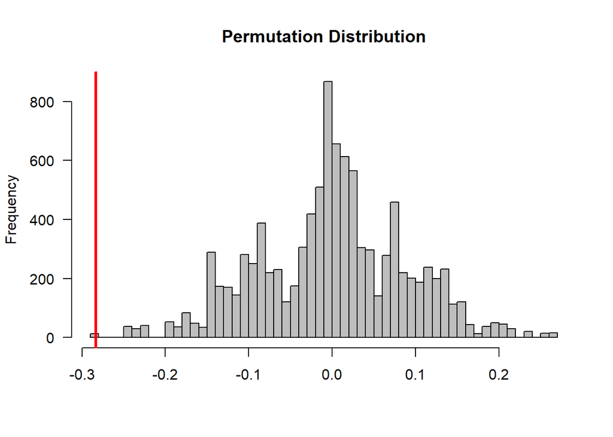

```r
test1 <- permutation.test(treatment, outcome, 10000)
hist(test1[[2]], breaks=50, col='grey', main="Permutation Distribution", las=1, xlab='')
abline(v=original, lwd=3, col="red")
```

```r
test1[[1]]
```

```
## [1] 0.0012
```

#### Duration

```r
# Generating data
set.seed(2022)

d1 <- data.frame(dat_3$duration, dat_3$chuckles)
colnames(d1) = c("V1", "V2")
treatment <- d1$V2
outcome <- d1$V1

#Difference in means
original <- diff(tapply(outcome, treatment, mean))
mean(outcome[treatment==1])-mean(outcome[treatment==0])
```

```
## [1] -2.604866
```

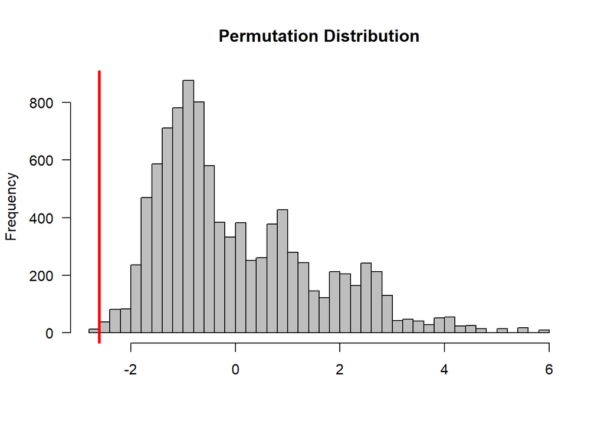

```r
test1 <- permutation.test(treatment, outcome, 10000)
hist(test1[[2]], breaks=50, col='grey', main="Permutation Distribution", las=1, xlab='')
abline(v=original, lwd=3, col="red")
```

```r
test1[[1]]
```

```
## [1] 0.0714
```

#### Bandwidth

```r
# Generating data
set.seed(2022)

d1 <- data.frame(dat_3$`IQR BW (Hz)_s`, dat_3$chuckles)
colnames(d1) = c("V1", "V2")
treatment <- d1$V2
outcome <- d1$V1

#Difference in means
original <- diff(tapply(outcome, treatment, mean))
mean(outcome[treatment==1])-mean(outcome[treatment==0])
```

```
## [1] 16.75278
```

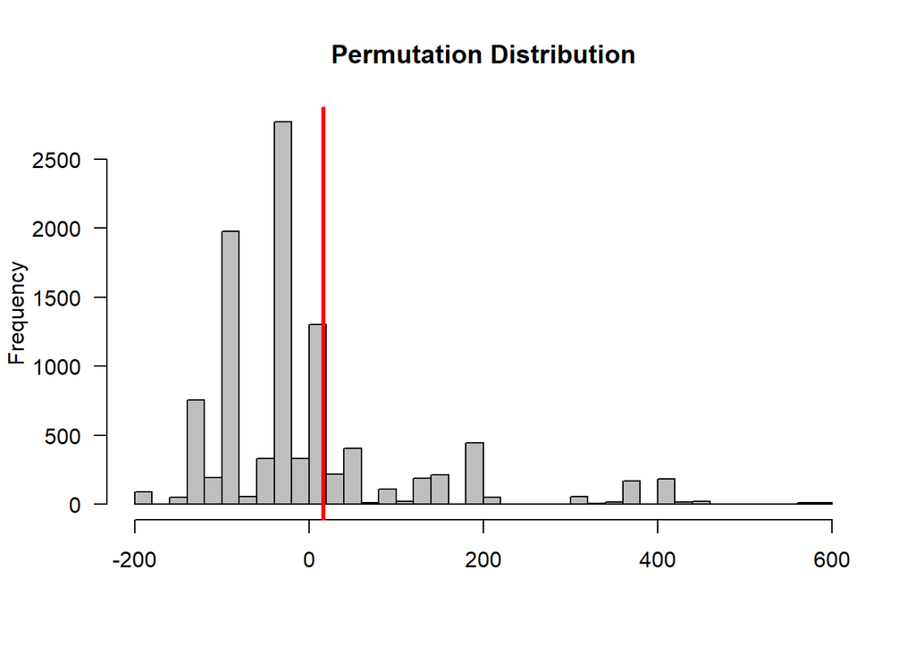

```r
test1 <- permutation.test(treatment, outcome, 10000)
hist(test1[[2]], breaks=50, col='grey', main="Permutation Distribution", las=1, xlab='')
abline(v=original, lwd=3, col="red")
```

```r
test1[[1]]
```

```
## [1] 0.9667
```

### 5.2 Permutation test : Rupert with towel vs Savannah Georgia female

#### Pulserate

```r
# Generating data
set.seed(2022)

dat_5 = dat_2 %>% filter(response == 1) %>% filter(chuckles == 0) %>% filter(`Units (notes)` > 1)
d1 <- data.frame(dat_5$pulserate, dat_5$`Owl ID #_s`)
colnames(d1) = c("V1", "V2")
treatment <- d1$V2
outcome <- d1$V1

#Difference in means
original <- diff(tapply(outcome, treatment, mean))
mean(outcome[treatment==1])-mean(outcome[treatment==0])
```

```
## [1] NaN
```

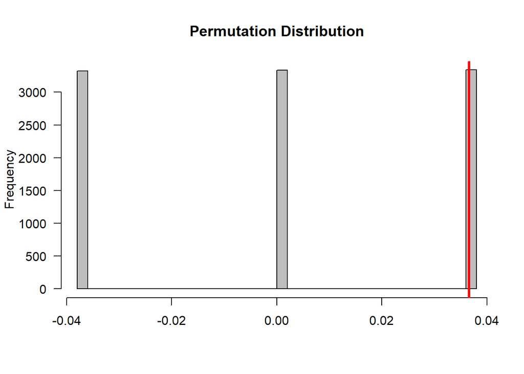

```r
test1 <- permutation.test(treatment, outcome, 10000)
hist(test1[[2]], breaks=50, col='grey', main="Permutation Distribution", las=1, xlab='')
abline(v=original, lwd=3, col="red")
```

```r
test1[[1]]
```

```
## [1] 0.6662
```

#### Duration

```r
# Generating data
set.seed(2022)

d1 <- data.frame(dat_5$duration, dat_5$`Owl ID #_s`)
colnames(d1) = c("V1", "V2")
treatment <- d1$V2
outcome <- d1$V1

#Difference in means
original <- diff(tapply(outcome, treatment, mean))
mean(outcome[treatment==1])-mean(outcome[treatment==0])
```

```
## [1] NaN
```

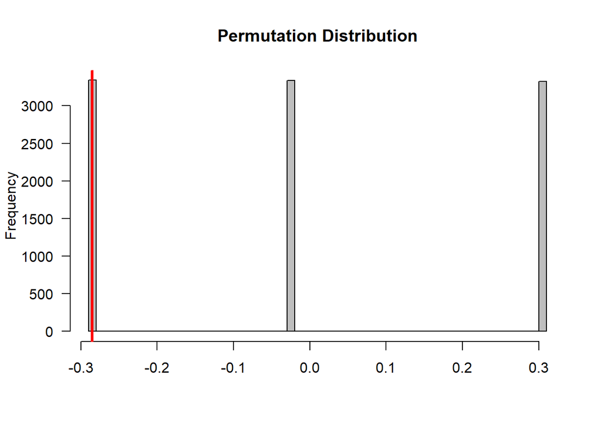

```r
test1 <- permutation.test(treatment, outcome, 10000)
hist(test1[[2]], breaks=50, col='grey', main="Permutation Distribution", las=1, xlab='')
abline(v=original, lwd=3, col="red")
```

```r
test1[[1]]
```

```
## [1] 0.6662
```

#### Bandwidth

```r
# Generating data
set.seed(2022)

d1 <- data.frame(dat_5$`IQR BW (Hz)_s`, dat_5$`Owl ID #_s`)
colnames(d1) = c("V1", "V2")
treatment <- d1$V2
outcome <- d1$V1

#Difference in means
original <- diff(tapply(outcome, treatment, mean))
mean(outcome[treatment==1])-mean(outcome[treatment==0])
```

```
## [1] NaN
```

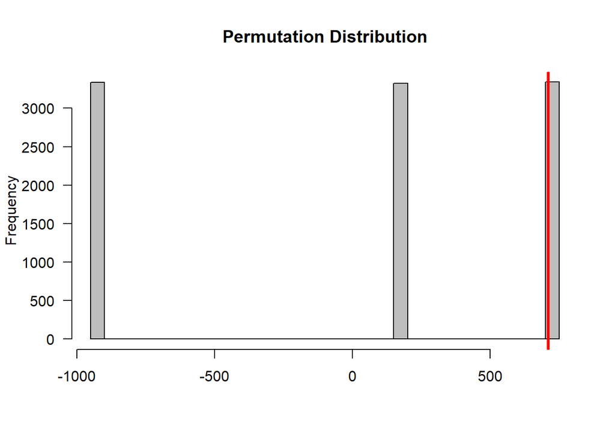

```r
test1 <- permutation.test(treatment, outcome, 10000)
hist(test1[[2]], breaks=50, col='grey', main="Permutation Distribution", las=1, xlab='')
abline(v=original, lwd=3, col="red")
```

```r
test1[[1]]
```

```
## [1] 0.6677
```

### 5.3 Rupert with towel vs all #1 vocalizations where units >1

#### Pulserate

```r
# Generating data
set.seed(2022)

dat_5 = dat_2 %>% filter(`Owl ID #_s` == 1) %>% filter(chuckles == 0) %>% filter(`Units (notes)` > 1)
d1 <- data.frame(dat_5$pulserate, dat_5$response)
colnames(d1) = c("V1", "V2")
treatment <- d1$V2
outcome <- d1$V1

#Difference in means
original <- diff(tapply(outcome, treatment, mean))
mean(outcome[treatment==1])-mean(outcome[treatment==0])
```

```
## [1] 0.009617499
```

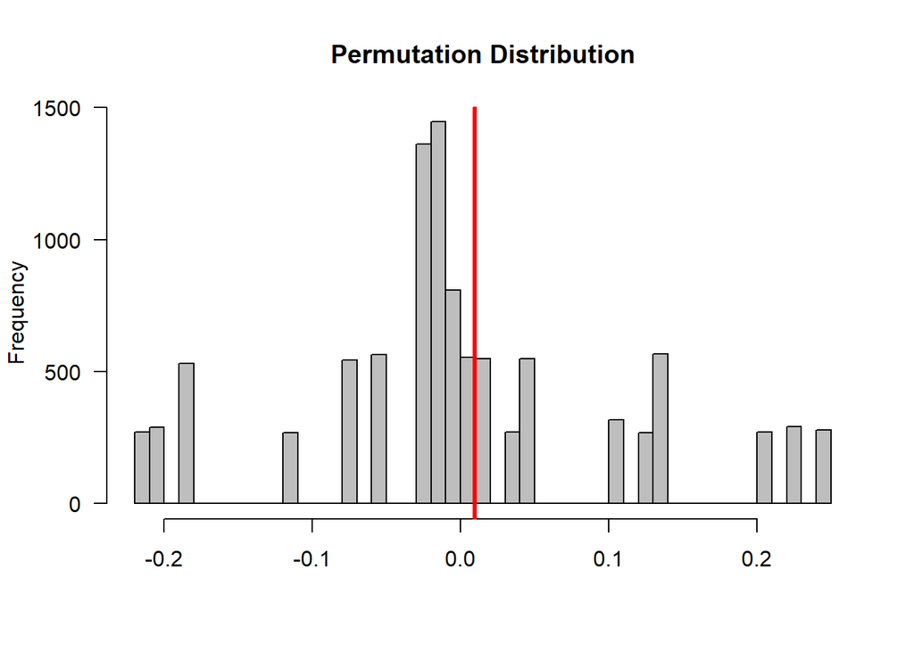

```r
test1 <- permutation.test(treatment, outcome, 10000)
hist(test1[[2]], breaks=50, col='grey', main="Permutation Distribution", las=1, xlab='')
abline(v=original, lwd=3, col="red")
```

```r
test1[[1]]
```

```
## [1] 0.889
```

#### Duration

```r
# Generating data
set.seed(2022)

d1 <- data.frame(dat_5$duration, dat_5$response)
colnames(d1) = c("V1", "V2")
treatment <- d1$V2
outcome <- d1$V1

#Difference in means
original <- diff(tapply(outcome, treatment, mean))
mean(outcome[treatment==1])-mean(outcome[treatment==0])
```

```
## [1] -0.8895766
```

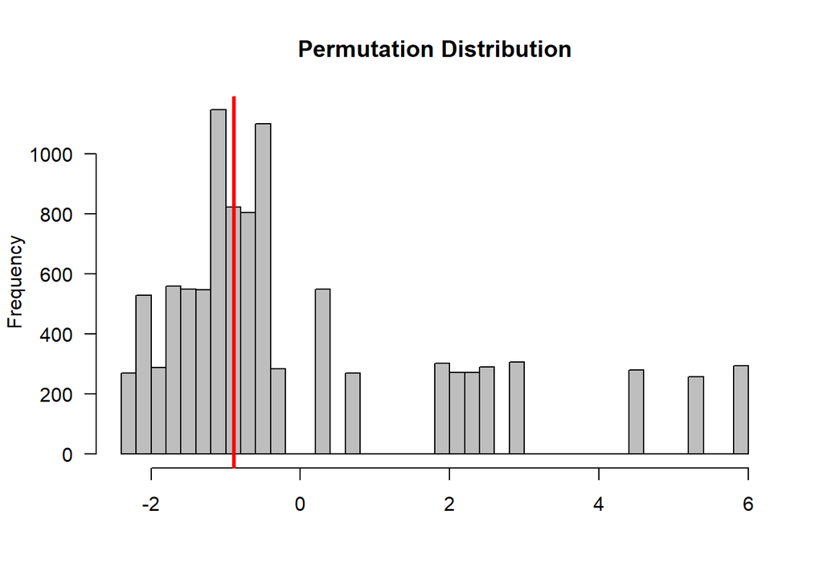

```r
test1 <- permutation.test(treatment, outcome, 10000)
hist(test1[[2]], breaks=50, col='grey', main="Permutation Distribution", las=1, xlab='')
abline(v=original, lwd=3, col="red")
```

```r
test1[[1]]
```

```
## [1] 0.6722
```

#### Bandwidth

```r
# Generating data
set.seed(2022)

d1 <- data.frame(dat_5$`IQR BW (Hz)_s`, dat_5$response)
colnames(d1) = c("V1", "V2")
treatment <- d1$V2
outcome <- d1$V1

#Difference in means
original <- diff(tapply(outcome, treatment, mean))
mean(outcome[treatment==1])-mean(outcome[treatment==0])
```

```
## [1] 74.52286
```

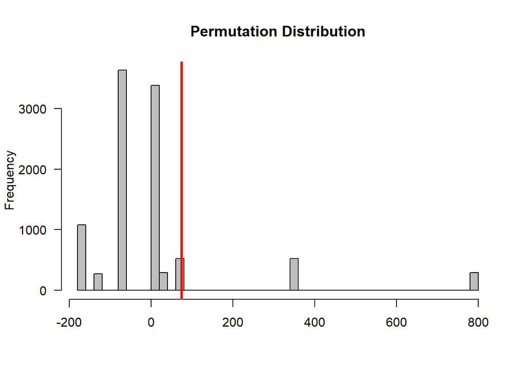

```r
test1 <- permutation.test(treatment, outcome, 10000)
hist(test1[[2]], breaks=50, col='grey', main="Permutation Distribution", las=1, xlab='')
abline(v=original, lwd=3, col="red")
```

```r
test1[[1]]
```

```
## [1] 0.6049
```

### 5.4 Savannah Georgia female vs all Savannah Georgia female vocalizations where Units>1.

#### Pulserate

```r
# Generating data
set.seed(2022)

dat_5 = dat_2 %>% filter(`Owl ID #_s` == 55) %>% filter(chuckles == 0) %>% filter(`Units (notes)` > 1)
d1 <- data.frame(dat_5$pulserate, dat_5$response)
colnames(d1) = c("V1", "V2")
treatment <- d1$V2
outcome <- d1$V1

#Difference in means
original <- diff(tapply(outcome, treatment, mean))
mean(outcome[treatment==1])-mean(outcome[treatment==0])
```

```
## [1] 0.03978567
```

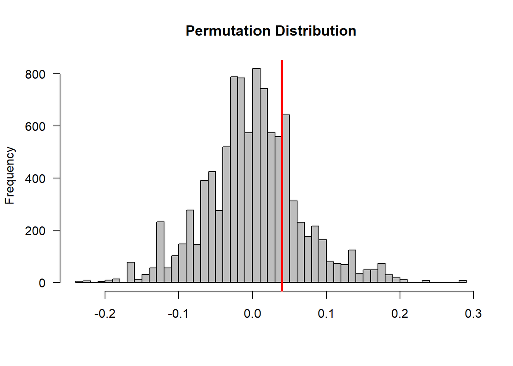

```r
test1 <- permutation.test(treatment, outcome, 10000)
hist(test1[[2]], breaks=50, col='grey', main="Permutation Distribution", las=1, xlab='')
abline(v=original, lwd=3, col="red")
```

```r
test1[[1]]
```

```
## [1] 0.4662
```

#### Duration

```r
# Generating data
set.seed(2022)

d1 <- data.frame(dat_5$duration, dat_5$response)
colnames(d1) = c("V1", "V2")
treatment <- d1$V2
outcome <- d1$V1

#Difference in means
original <- diff(tapply(outcome, treatment, mean))
mean(outcome[treatment==1])-mean(outcome[treatment==0])
```

```
## [1] -2.053834
```

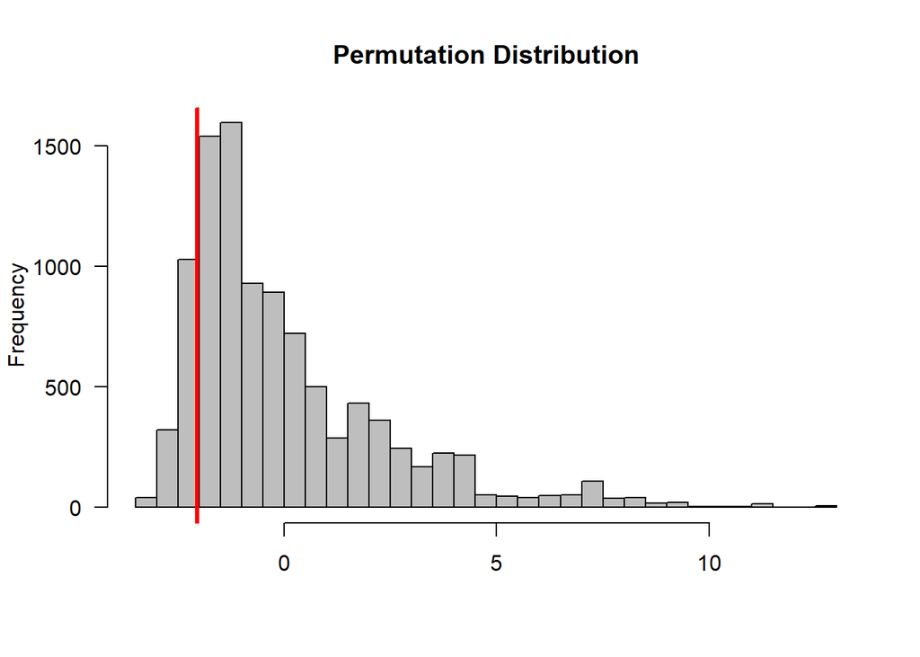

```r
test1 <- permutation.test(treatment, outcome, 10000)
hist(test1[[2]], breaks=50, col='grey', main="Permutation Distribution", las=1, xlab='')
abline(v=original, lwd=3, col="red")
```

```r
test1[[1]]
```

```
## [1] 0.2918
```

#### Bandwidth

```r
# Generating data
set.seed(2022)

d1 <- data.frame(dat_5$`IQR BW (Hz)_s`, dat_5$response)
colnames(d1) = c("V1", "V2")
treatment <- d1$V2
outcome <- d1$V1

#Difference in means
original <- diff(tapply(outcome, treatment, mean))
mean(outcome[treatment==1])-mean(outcome[treatment==0])
```

```
## [1] 518.8167
```

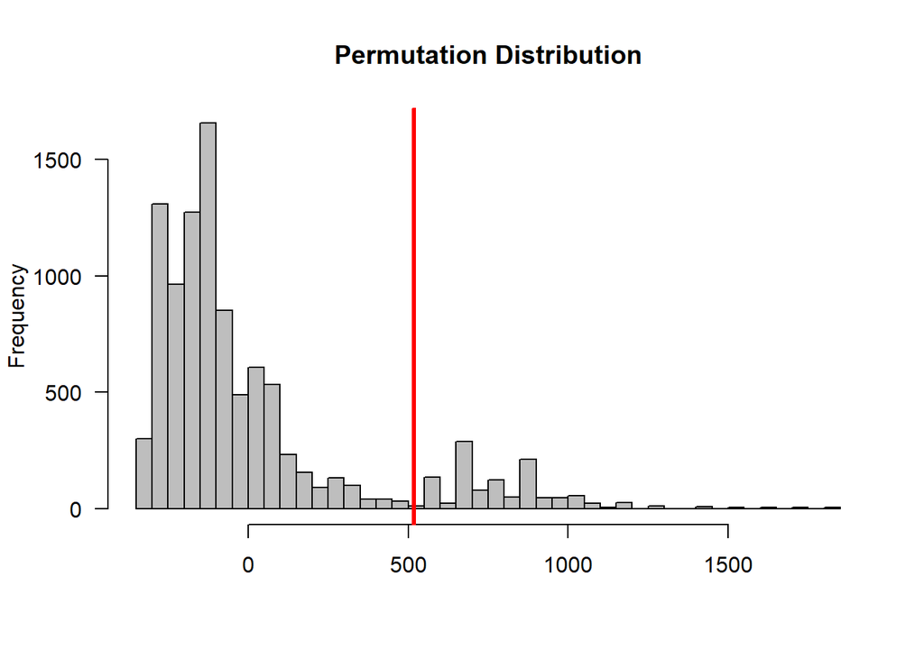

```r
test1 <- permutation.test(treatment, outcome, 10000)
hist(test1[[2]], breaks=50, col='grey', main="Permutation Distribution", las=1, xlab='')
abline(v=original, lwd=3, col="red")
```

```r
test1[[1]]
```

```
## [1] 0.1182
```

### 5.5 Rupert vs. ((all ID #1 and all ID #55) where units > 1)

#### Pulserate

```r
# Generating data
set.seed(2022)

dat_3 = dat_2 %>% filter(`Owl ID #_s` %in% c(1,55)) %>% filter(`Units (notes)` > 1)
d1 <- data.frame(dat_3$pulserate, dat_3$chuckles)
colnames(d1) = c("V1", "V2")
treatment <- d1$V2
outcome <- d1$V1

#Difference in means
original <- diff(tapply(outcome, treatment, mean))
mean(outcome[treatment==1])-mean(outcome[treatment==0])
```

```
## [1] -0.2879673
```

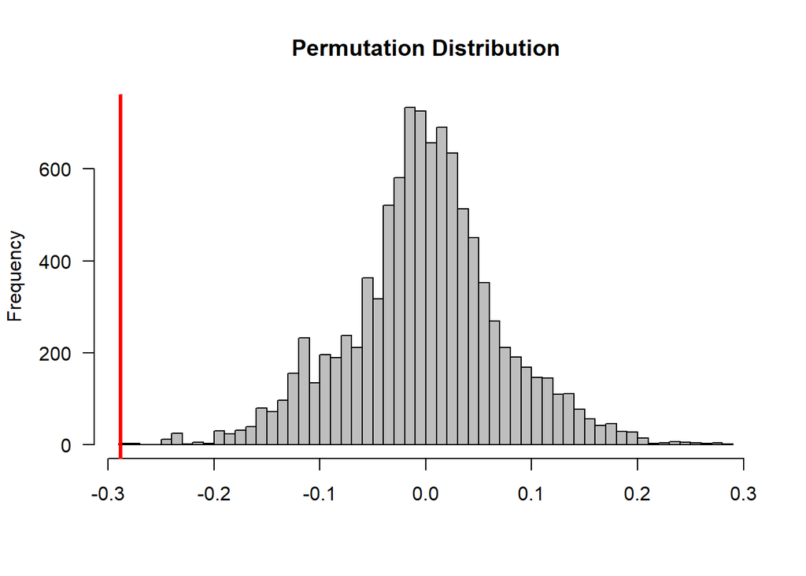

```r
test1 <- permutation.test(treatment, outcome, 10000)
hist(test1[[2]], breaks=50, col='grey', main="Permutation Distribution", las=1, xlab='')
abline(v=original, lwd=3, col="red")
```

```r
test1[[1]]
```

```
## [1] 4e-04
```

#### Duration

```r
# Generating data
set.seed(2022)

d1 <- data.frame(dat_3$duration, dat_3$chuckles)
colnames(d1) = c("V1", "V2")
treatment <- d1$V2
outcome <- d1$V1

#Difference in means
original <- diff(tapply(outcome, treatment, mean))
mean(outcome[treatment==1])-mean(outcome[treatment==0])
```

```
## [1] -3.166306
```

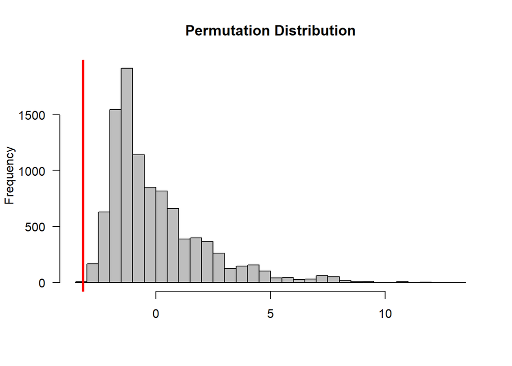

```r
test1 <- permutation.test(treatment, outcome, 10000)
hist(test1[[2]], breaks=50, col='grey', main="Permutation Distribution", las=1, xlab='')
abline(v=original, lwd=3, col="red")
```

```r
test1[[1]]
```

```
## [1] 0.0802
```

#### Bandwidth

```r
# Generating data
set.seed(2022)

d1 <- data.frame(dat_3$`IQR BW (Hz)_s`, dat_3$chuckles)
colnames(d1) = c("V1", "V2")
treatment <- d1$V2
outcome <- d1$V1

#Difference in means
original <- diff(tapply(outcome, treatment, mean))
mean(outcome[treatment==1])-mean(outcome[treatment==0])
```

```
## [1] -168.2458
```

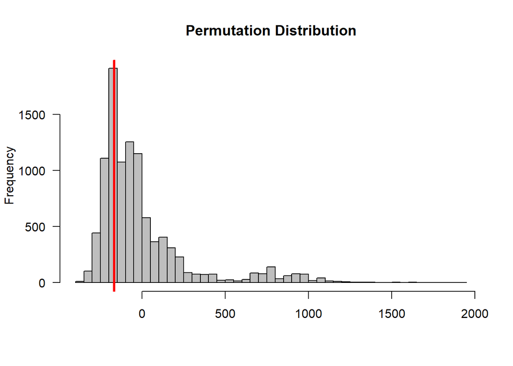

```r
test1 <- permutation.test(treatment, outcome, 10000)
hist(test1[[2]], breaks=50, col='grey', main="Permutation Distribution", las=1, xlab='')
abline(v=original, lwd=3, col="red")
```

```r
test1[[1]]
```

```
## [1] 0.425
```

### 5.6 Rupert vs Savannah Gerogia female

```r
dat_5_6 = rbind(dat_ch, dat_nch2)
dat_5_6$`Owl ID #_s` = c(1,1,55,55)
```

#### Pulserate

```r
# Generating data
set.seed(2022)

d1 <- data.frame(dat_5_6$pulserate, dat_5_6$chuckles)
colnames(d1) = c("V1", "V2")
treatment <- d1$V2
outcome <- d1$V1

#Difference in means
original <- diff(tapply(outcome, treatment, mean))
mean(outcome[treatment==1])-mean(outcome[treatment==0])
```

```
## [1] -0.329075
```

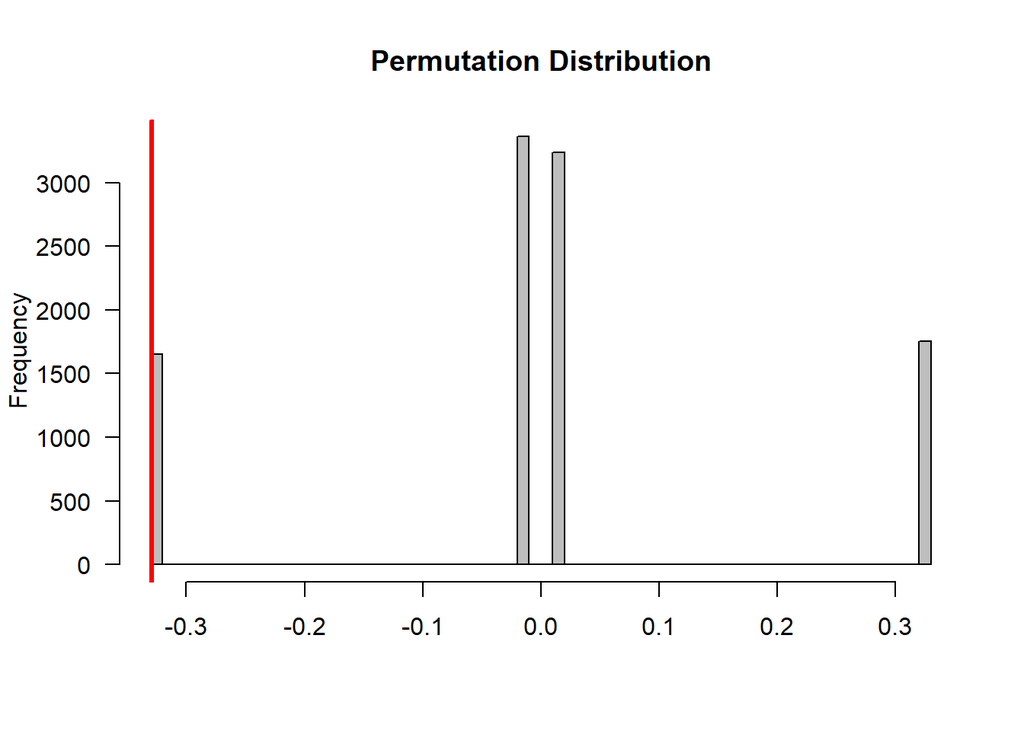

```r
test1 <- permutation.test(treatment, outcome, 10000)
hist(test1[[2]], breaks=50, col='grey', main="Permutation Distribution", las=1, xlab='')
abline(v=original, lwd=3, col="red")
```

```r
test1[[1]]
```

```
## [1] 0.3403
```

#### Duration

```r
# Generating data
set.seed(2022)

d1 <- data.frame(dat_5_6$duration, dat_5_6$chuckles)
colnames(d1) = c("V1", "V2")
treatment <- d1$V2
outcome <- d1$V1

#Difference in means
original <- diff(tapply(outcome, treatment, mean))
mean(outcome[treatment==1])-mean(outcome[treatment==0])
```

```
## [1] -1.455
```

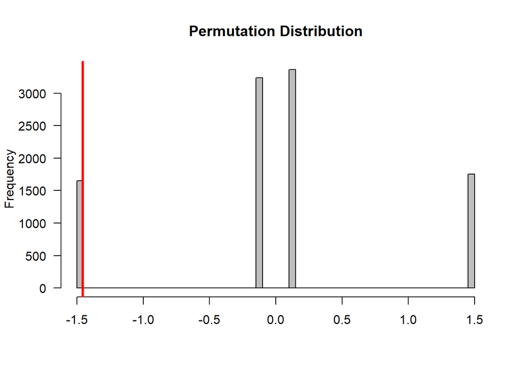

```r
test1 <- permutation.test(treatment, outcome, 10000)
hist(test1[[2]], breaks=50, col='grey', main="Permutation Distribution", las=1, xlab='')
abline(v=original, lwd=3, col="red")
```

```r
test1[[1]]
```

```
## [1] 0.3403
```

#### Bandwidth

```r
# Generating data
set.seed(2022)

d1 <- data.frame(dat_5_6$`IQR BW (Hz)_s`, dat_5_6$chuckles)
colnames(d1) = c("V1", "V2")
treatment <- d1$V2
outcome <- d1$V1

#Difference in means
original <- diff(tapply(outcome, treatment, mean))
mean(outcome[treatment==1])-mean(outcome[treatment==0])
```

```
## [1] -766.25
```

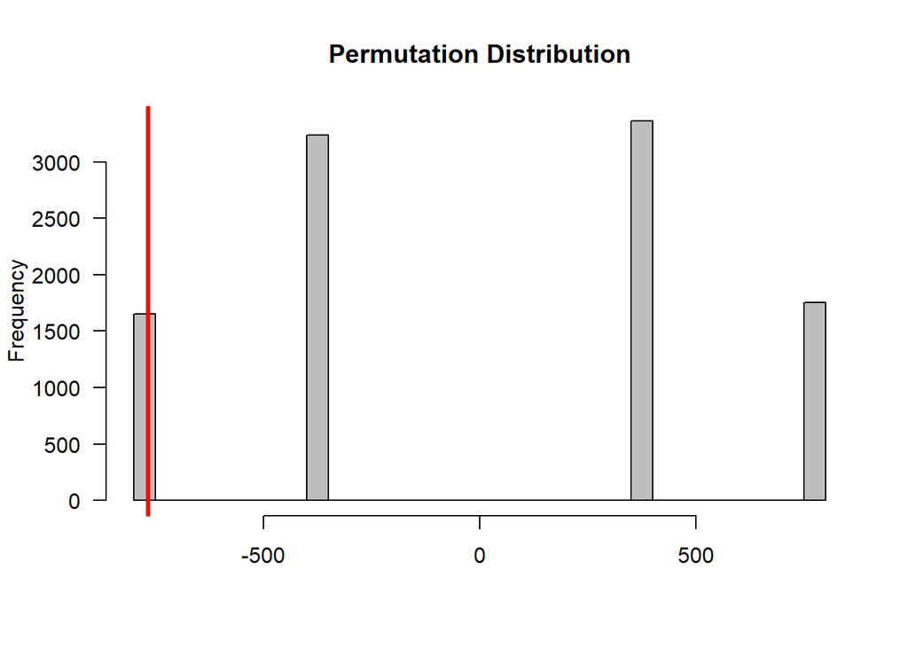

```r
test1 <- permutation.test(treatment, outcome, 10000)
hist(test1[[2]], breaks=50, col='grey', main="Permutation Distribution", las=1, xlab='')
abline(v=original, lwd=3, col="red")
```

```r
test1[[1]]
```

```
## [1] 0.3403
```

### 5.7 Rupert vs Rupert with towel

```r
dat_5_7 = rbind(dat_ch, dat_nch1)
```

#### Pulserate

```r
# Generating data
set.seed(2022)

d1 <- data.frame(dat_5_7$pulserate, dat_5_7$chuckles)
colnames(d1) = c("V1", "V2")
treatment <- d1$V2
outcome <- d1$V1

#Difference in means
original <- diff(tapply(outcome, treatment, mean))
mean(outcome[treatment==1])-mean(outcome[treatment==0])
```

```
## [1] -0.2925
```

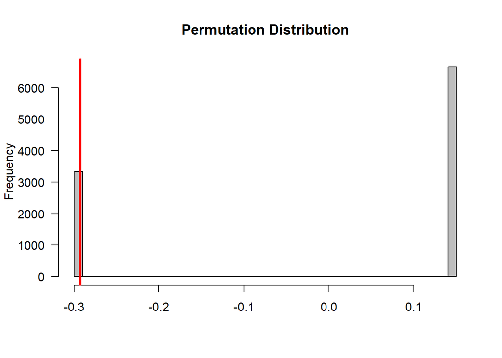

```r
test1 <- permutation.test(treatment, outcome, 10000)
hist(test1[[2]], breaks=50, col='grey', main="Permutation Distribution", las=1, xlab='')
abline(v=original, lwd=3, col="red")
```

```r
test1[[1]]
```

```
## [1] 0.3339
```

#### Duration

```r
# Generating data
set.seed(2022)

d1 <- data.frame(dat_5_7$duration, dat_5_7$chuckles)
colnames(d1) = c("V1", "V2")
treatment <- d1$V2
outcome <- d1$V1

#Difference in means
original <- diff(tapply(outcome, treatment, mean))
mean(outcome[treatment==1])-mean(outcome[treatment==0])
```

```
## [1] -1.74
```

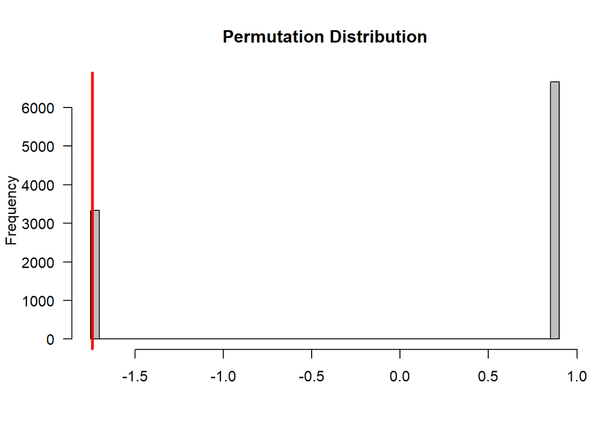

```r
test1 <- permutation.test(treatment, outcome, 10000)
hist(test1[[2]], breaks=50, col='grey', main="Permutation Distribution", las=1, xlab='')
abline(v=original, lwd=3, col="red")
```

```r
test1[[1]]
```

```
## [1] 0.3339
```

#### Bandwidth

```r
# Generating data
set.seed(2022)

d1 <- data.frame(dat_5_7$`IQR BW (Hz)_s`, dat_5_7$chuckles)
colnames(d1) = c("V1", "V2")
treatment <- d1$V2
outcome <- d1$V1

#Difference in means
original <- diff(tapply(outcome, treatment, mean))
mean(outcome[treatment==1])-mean(outcome[treatment==0])
```

```
## [1] -55.7
```

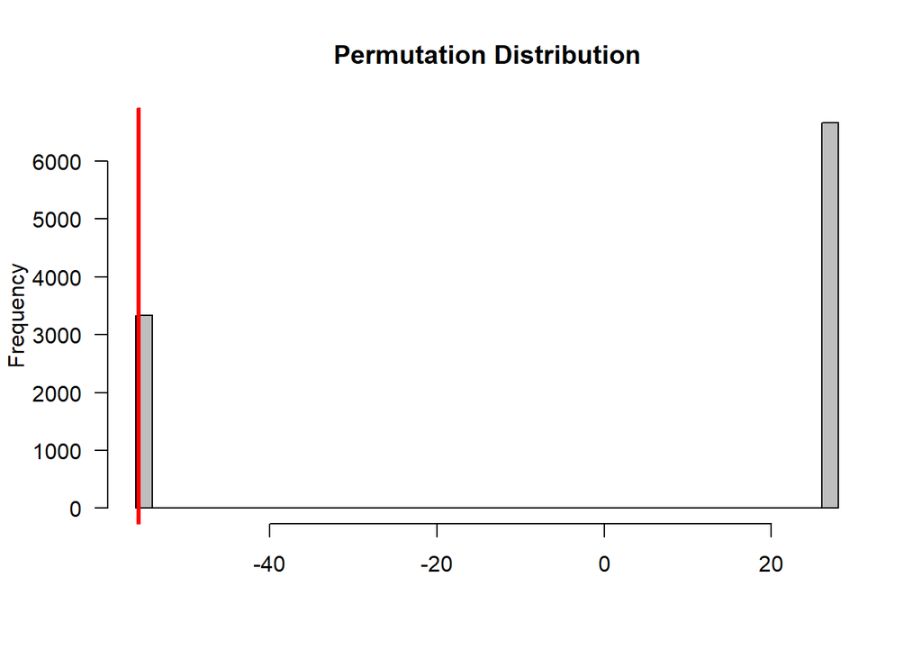

```r
test1 <- permutation.test(treatment, outcome, 10000)
hist(test1[[2]], breaks=50, col='grey', main="Permutation Distribution", las=1, xlab='')
abline(v=original, lwd=3, col="red")
```

```r
test1[[1]]
```

```
## [1] 0.3339
```